# Yellowmouth Rockfish

*Sebastes reedi*

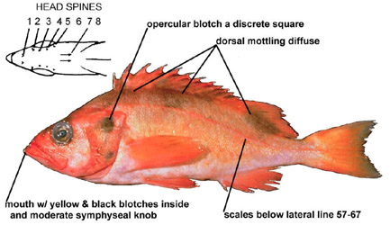

**Body color:** Red intermixed w/ yellow-orange (or black in individuals < 40cm); diffuse olivaceous mottling on back; mouth w/ yellow, red and black blotches on whitish background.

**Peritoneum color:** silver w/black dots **Shape between eyes:** convex to flat

**Counts:** D:XIII,13-15, Ar:7-8, P1:18-20, GR:30-36, LLp:47-55, LLs:57-67, V:26

**Occurence:** Gulf of Alaska - Central California

**Depth:** 141-366 meters **Size:** 51 cm **Species code:** 30600

**Similar species:**

- *Pacific Ocean Perch* - symphyseal knob sharp, elongate; no yellow blotches inside mouth; dorsal blotches discrete, opercular blotch diffuse; 43-55 scales below lateral line
- *Redstripe rockfish* - lateral line light, contrasted by dark mottling above and below; head spine count differs; gillrakers 36-43 (30-36 in Yellowmouth)
- *Chilipepper rockfish* - no dorsal blotches; head spine count differs; belly whitish
- *Sharpchin rockfish* - dorsal blotches large w/ at least one extending across lateral line; forked bar radiates posteriorly from eye; head spines strong and count differs; 43-50 scales below lateral line; anal spine 2 longer than 3
- *Rougheye rockfish, Shortraker rockfish, and Blackgill rockfish* - head spines strong and count differs; 47-55 scales below lateral line; 0-8 spines below eye

Back to Group

**Corrections:** If you see mistakes or want to suggest changes, please create an [issue](https://github.com/zoyafuso-NOAA/RACE_Survey_App/issues) on the source repository or

*reach out to Liz Dawson (Liz.Dawson AT noaa.gov).*